# Test_a_Perceptual_Phenomenon

## Test a Perceptual Phenomenon

```python
# Import libraries necessary for this project
import numpy as np
import pandas as pd
import math
import matplotlib.pyplot as plt
plt.style.use('ggplot')
%matplotlib inline
```

```python
# Import the data from CSV file
df = pd.read_csv('stroopdata.csv')
df.head()
```

|  | Congruent | Incongruent |
| --- | --- | --- |
| 0 | 12.079 | 19.278 |
| 1 | 16.791 | 18.741 |
| 2 | 9.564 | 21.214 |
| 3 | 8.630 | 15.687 |
| 4 | 14.669 | 22.803 |

```python
print "Number of samples in this dataset:", len(df)
```

```
Number of samples in this dataset: 24
```

### 1. What is our independent variable? What is our dependent variable?

Independent Variables: Congruent and incongruent words condition  
Dependent Variable: Response time to name the ink colors of the words

### 2. What is an appropriate set of hypotheses for this task? What kind of statistical test do you expect to perform? Justify your choices.

μC: Population mean response time of congruent words condition  
μI: Population mean response time of incongruent words condition

Null hypothesis, H0: μC=μI

- There is no difference in the population mean response time between congurent and incongurent conditions

Alternative Hypothesis, H1: μC≠μI

- The population mean reaction time in incongurent condition is significantly different from congurent condition

**Two-tailed dependent t-test** is chosen because:

- we would like to compare the means of the paired samples to determine whether there is a statistically significant difference between these means
- we do not the know the population variance and the sample size is less than 30
- we expect the distribution of the population is normal or approximately normal

### 3. Report some descriptive statistics regarding this dataset. Include at least one measure of central tendency and at least one measure of variability.

```python
# Descriptive statistics of congruent words response time
df['Congruent'].describe()
```

```
count    24.000000
mean     14.051125
std       3.559358
min       8.630000
25%      11.895250
50%      14.356500
75%      16.200750
max      22.328000
Name: Congruent, dtype: float64
```

```python
# Descriptive statistics of incongruent words response time
df['Incongruent'].describe()
```

```
count    24.000000
mean     22.015917
std       4.797057
min      15.687000
25%      18.716750
50%      21.017500
75%      24.051500
max      35.255000
Name: Incongruent, dtype: float64
```

### 4. Provide one or two visualizations that show the distribution of the sample data. Write one or two sentences noting what you observe about the plot or plots.

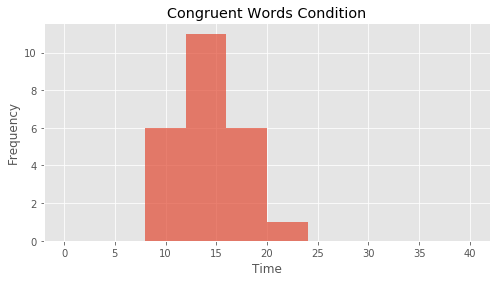

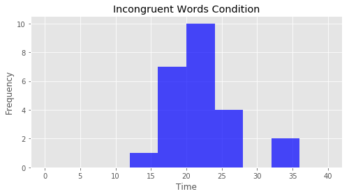

```python
# Histogram plot
df['Congruent'].hist(bins=10, alpha=0.7, figsize=(8, 4),range=[0,40])
plt.title('Congruent Words Condition')
plt.xlabel('Time')
plt.ylabel('Frequency')

plt.figure()
df['Incongruent'].hist(bins=10, color = 'blue', alpha=0.7, figsize=(8,4),range=[0,40])
plt.title('Incongruent Words Condition')
plt.xlabel('Time')
plt.ylabel('Frequency')
```

The histogram plots that look like bell shape indicate that the response time of the sample data are approximately normal distribution for both congruent and incongruent word conditions

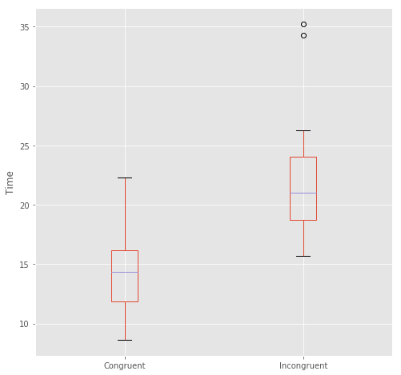

```python
# Box plot
df.plot.box(figsize=(8,8))
plt.ylabel('Time')
```

From the boxplot, we can see that the time taken in incongruent condition is generally longer in comparison to congruent condition.

### 5. Now, perform the statistical test and report your results. What is your confidence level and your critical statistic value? Do you reject the null hypothesis or fail to reject it? Come to a conclusion in terms of the experiment task. Did the results match up with your expectations?

Let's use 5% level of significant.  
degree of freedom, df = 24 - 1 = 23  
Using the t-distribution, the two-tailed critical t-values for a 5% level of significant with df = 23 is ±2.069.

The decision rule:  
Reject H0 if t-statistic <-2.069, or t-statistic > 2.069

```python
mean_diff = (df['Incongruent']-df['Congruent']).mean()
sd_diff = (df['Congruent']-df['Incongruent']).std()
t_statistic = mean_diff/(sd_diff/math.sqrt(len(df)))

print "t-statistic: {:,.3f} ".format(t_statistic)
```

```
t-statistic: 8.021
```

The computed t-statistic, 8.021 is greater than the critical t-value 2.069 – it falls in the rejection region.  
Thus, we reject the null hypothesis of no difference, concluding that there *is* a statistically significant difference between the mean response time of congruent and incongurent conditions.  
These are the results I expected since I also have longer reaction time to name the color in incongurent words condition.